# Those Poor Manatees

Gina Nichols

7/28/2020

# Easy

## 8E1.

**Name a hypothetical 3rd variable that could lead to an interaction** - bread dough rising *FERNANDO THIS IS FOR YOU!* because of yeast could depend on the **temperature** - education leading to higher income, could depend on **your socio-economic status before your eduction** - gasoline makes a car go, could depend on *the status of the gas pedal*

## 8E2.

**Which explanation invokes an interaction?** 4 is the only one that doesn’t, I think

## 8E3

$onion\ carmelization = \alpha + \beta_{heat}(Heat) + \beta_{mois}(Mois) + \beta_{heat,moist}(Heat)(Mois)$ That’s enough of that.

# Medium

## 8M1

**Add temperature to the tulips (shade, water)** The main effects of shade and water, as well as their interaction, depend on the temperature.

## 8M2

**What is an example of a masked relationship?** I’m struggling with these.

## 8M3

**Invent a reression that makes bloom size 0 if the temperature is hot** $relative\_bloom\_size_i = (1 - Heatstress_i)(\alpha + \beta_{shade}(shade_i) + \beta_{water}(water_i) + \beta_{shade,water}(shade_i)(water_i)$

## 8M4

**Force water effect to be positive and shade effect to be negative.** Remember rlnorm can be used to force things to be positive (page 96).

```r
data(tulips)
dt <- tulips %>%
  as_tibble() %>%
  mutate(blooms_std = blooms / max(blooms), #-don't standardize if 0 is meaninful. Like with ruggedness, only scale it
         water_cent = water - mean(water),
         shade_cent = shade - mean(shade))

dt
```

```
## # A tibble: 27 x 7
##    bed   water shade blooms blooms_std water_cent shade_cent
##    <fct> <int> <int>  <dbl>      <dbl>      <dbl>      <dbl>
##  1 a         1     1    0        0             -1         -1
##  2 a         1     2    0        0             -1          0
##  3 a         1     3  111.       0.307         -1          1
##  4 a         2     1  183.       0.507          0         -1
##  5 a         2     2   59.2      0.164          0          0
##  6 a         2     3   76.8      0.212          0          1
##  7 a         3     1  225.       0.622          1         -1
##  8 a         3     2   83.8      0.232          1          0
##  9 a         3     3  135.       0.373          1          1
## 10 b         1     1   80.1      0.221         -1         -1
## # ... with 17 more rows
```

Try original priors first:

```r
m_tul1 <- quap(
  alist(
    blooms_std <- dnorm(mu, sigma),
    mu <- a + bw*water_cent + bs*shade_cent + bws*water_cent*shade_cent,
    a ~ dnorm(0.5, 0.25),
    bw ~ dnorm(0, 0.25),
    bs ~ dnorm(0, 0.25),
    bws ~ dnorm(0, 0.25),
    sigma ~ dexp(1)
  ), data = dt)
```

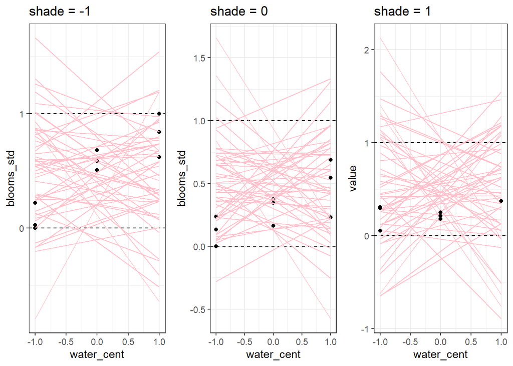

Try adjusting priors. First just make water thing positive:

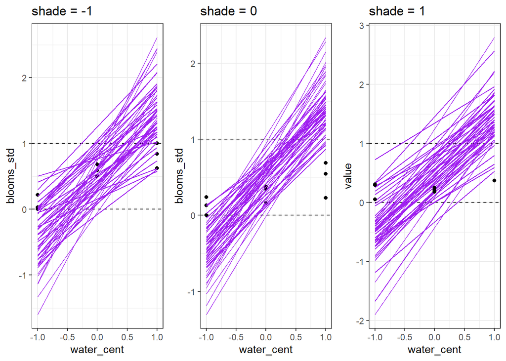

```r
m_tul2 <- quap(
  alist(
    blooms_std <- dnorm(mu, sigma),
    mu <- a + bw*water_cent + bs*shade_cent + bws*water_cent*shade_cent,
    a ~ dnorm(0.5, 0.25),
    bw ~ dlnorm(0, 0.25), #--make this always positive
    bs ~ dnorm(0, 0.25),
    bws ~ dnorm(0, 0.25),
    sigma ~ dexp(1)
  ), data = dt)

f_shade_priors(mymodel = m_tul2, mycolor = "purple")
```

Oof those slopes are way to dramatic. Try restricting them:

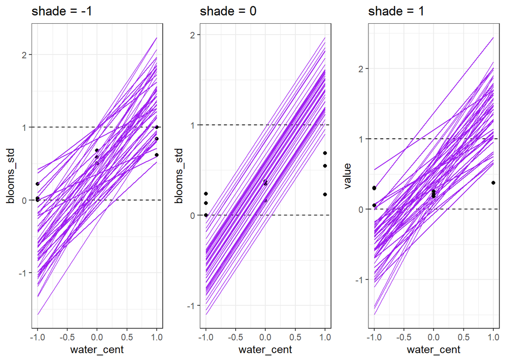

```r
m_tul2a <- quap(
  alist(
    blooms_std <- dnorm(mu, sigma),
    mu <- a + bw*water_cent + bs*shade_cent + bws*water_cent*shade_cent,
    a ~ dnorm(0.5, 0.25),
    bw ~ dlnorm(0, 0.001), #--make this always positive, smaller range?
    bs ~ dnorm(0, 0.25),
    bws ~ dnorm(0, 0.25),
    sigma ~ dexp(1)
  ), data = dt)

f_shade_priors(mymodel = m_tul2a, mycolor = "purple")
```

Maybe it has to be in tandem with the shade being negative.

First water positive and shade negative try #1:

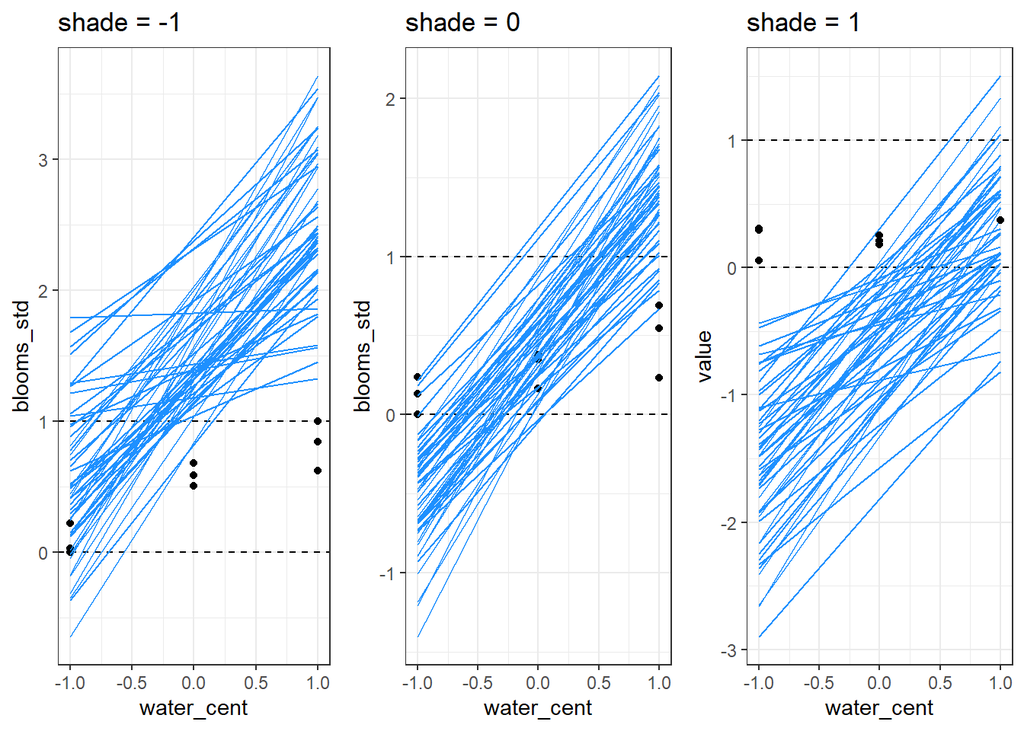

```r
m_tul3 <- quap(
  alist(
    blooms_std <- dnorm(mu, sigma),
    mu <- a + bw*water_cent - bs*shade_cent + bws*water_cent*shade_cent,
    a ~ dnorm(0.5, 0.25),
    bw ~ dlnorm(0, 0.25), #--make this always positive
    bs ~ dlnorm(0, 0.25), #--make this always pos, but it's subtracted (?)
    bws ~ dnorm(0, 0.25),
    sigma ~ dexp(1)
  ), data = dt)

f_shade_priors(mymodel = m_tul3, mycolor = "dodgerblue")
```